# Significant methylation gene annotation

RSTR vs. LTBI, full dataset

Kim Dill-McFarland, kadm@uw.edu

version November 17, 2022

# Setup

Load packages

```r
# Data manipulation and figures
library(tidyverse)
library(BIGpicture)
library(ggrepel)
# Annotation
library(biomaRt)
library(org.Hs.eg.db)
# Enrichment
library(SEARchways)
library(rrvgo)
library(GO.db)
#Print pretty tables to Rmd
library(knitr)
library(kableExtra)
  options(knitr.kable.NA = '')
```

Set seed

```r
set.seed(589)
```

# Load data

```r
DMP <- read_csv("results/RSTR.DMP.results.csv.gz",
                col_types = cols(CHR="c"))
DMR <- read_csv("results/RSTR.DMR.results.cpgs.csv.gz")
```

# Significant genes

List significant genes

```r
DMP.fdr <- 0.2
#DMP genes
DMP.signif <- DMP %>%
  filter(FDR <= DMP.fdr & feature != "IGR") %>%
  mutate(gene_to_use = ifelse(is.na(gene),gene_HGNC_hg38, gene)) %>%
  distinct(gene_to_use) %>%
  mutate(gene_to_use = str_split(gene_to_use, ";")) %>%
  unnest(gene_to_use) %>%
  drop_na(gene_to_use) %>%
  dplyr::rename(hgnc_symbol = gene_to_use) %>%
  mutate(group="DMP")
#DMR genes
DMR.signif <- DMR %>%
  filter( annotation.group != "IGR") %>%
  distinct(DMR_genes) %>%
  mutate(DMR_genes = str_split(DMR_genes, "/")) %>%
  unnest(DMR_genes)  %>%
  drop_na(DMR_genes) %>%
  dplyr::rename(hgnc_symbol = DMR_genes) %>%
  mutate(group="DMR")

#Combine
signif.all <- bind_rows(DMP.signif, DMR.signif) %>%
  dplyr::select(group, hgnc_symbol)

overlap <- intersect(DMP.signif$hgnc_symbol, DMR.signif$hgnc_symbol)
```

DMP and DMR-associated genes

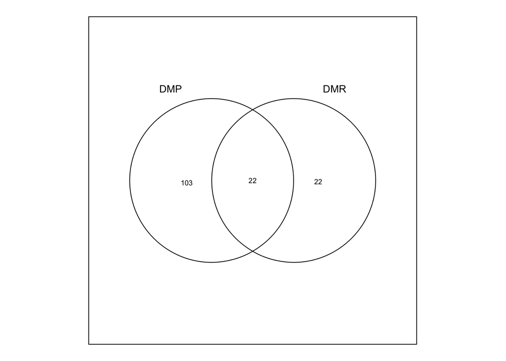

```r
venn::venn(list("DMP"=DMP.signif$hgnc_symbol, "DMR"=DMR.signif$hgnc_symbol))
```

Add ENSEMBL, ENTREZ, and location data.

```r
#Get reference genome
ensembl <- useMart("ensembl", dataset = "hsapiens_gene_ensembl",
                   host = "https://useast.ensembl.org")
  #Check genome version
  searchDatasets(mart = ensembl, pattern = "hsapiens")
```

```
##                  dataset              description    version
## 81 hsapiens_gene_ensembl Human genes (GRCh38.p13) GRCh38.p13
```

```r
#Get HGNC symbols and gene positions
gene.POS <- getBM(attributes = c('hgnc_symbol', 'ensembl_gene_id',
                                 'entrezgene_id',
                                 'chromosome_name',
                                'start_position','end_position',
                                'strand'),
      mart = ensembl) %>%
  #Rename
  dplyr::rename(CHR=chromosome_name) %>%
  #Calculate max range of positions from multi-annotations
  filter(!grepl("CHR", CHR)) %>%
  group_by(CHR, hgnc_symbol, ensembl_gene_id, entrezgene_id,
           strand) %>%
  summarise(min.start = min(start_position, na.rm=TRUE),
            max.end = max(end_position, na.rm=TRUE), .groups = "drop")

#annotate signif genes
signif.anno <- signif.all %>%
  left_join(gene.POS, by="hgnc_symbol")
```

## Hypergeometric enrichment

Broad terms enriched in DMP / DMP genes

#### Gene set descriptions

- Hallmark gene sets (H)
  - Hallmark gene sets summarize and represent specific well-defined biological states or processes and display coherent expression. These gene sets were generated by a computational methodology based on identifying overlaps between gene sets in other MSigDB collections and retaining genes that display coordinate expression.
- Basic gene sets (C5)
  - Gene sets that contain genes annotated by the same GO term. Includes:
  - BP: biological process
  - CC: cellular component
  - MF: molecular function
- Curated gene sets (C2)
  - Gene sets curated from various sources including online pathway databases, the biomedical literature, and knowledge of domain experts. Includes:
  - CP: Canonical pathways
    - BIOCARTA: BioCarta gene sets
    - KEGG: KEGG gene sets
    - PID: PID gene sets
    - REACTOME: Reactome gene sets

### Run enrichment

Convert genes to list object

```r
gene.list <- list()
#All signif genes
gene.list[["DMP/R"]] <- signif.anno %>%
   pull(hgnc_symbol) %>% unique()
gene.list[["DMP"]] <- signif.anno %>%
  filter(group == "DMP") %>% pull(hgnc_symbol) %>% unique()
gene.list[["DMR"]] <- signif.anno %>%
  filter(group == "DMR") %>% pull(hgnc_symbol) %>% unique()
```

#### Hallmark (H)

```r
enrichH <- BIGprofiler(gene.list, ID = "SYMBOL",
                       category = "H")
```

#### Basic gene sets (C5)

```r
enrichC5 <- BIGprofiler(gene.list, ID = "SYMBOL",
                        category = "C5", subcategory = "GO:BP")
```

### Enrichment summary

| Gene set | Group | Genes in group | Description | Genes in term | Genes overlap | Genes | k/K | FDR |
| --- | --- | --- | --- | --- | --- | --- | --- | --- |
| C5 | DMR | 44 | GOBP_COCHLEA_DEVELOPMENT | 49 | 2 | MCM2 , KCNQ1 | 0.0408163 | 0.1792264 |
| C5 | DMR | 44 | GOBP_PROTEIN_LIPID_COMPLEX_SUBUNIT_ORGANIZATION | 49 | 2 | APOC3 , PLA2G3 | 0.0408163 | 0.1792264 |
| C5 | DMR | 44 | GOBP_REGULATION_OF_FATTY_ACID_BIOSYNTHETIC_PROCESS | 49 | 2 | APOC3 , PLA2G3 | 0.0408163 | 0.1792264 |
| C5 | DMR | 44 | GOBP_RHYTHMIC_BEHAVIOR | 45 | 2 | PER3 , KCNQ1 | 0.0444444 | 0.1792264 |
| C5 | DMR | 44 | GOBP_LIPID_EXPORT_FROM_CELL | 43 | 2 | PLA2G3, KCNQ1 | 0.0465116 | 0.1792264 |
| C5 | DMR | 44 | GOBP_HIPPO_SIGNALING | 40 | 2 | SHANK2, CIT | 0.0500000 | 0.1792264 |
| C5 | DMR | 44 | GOBP_BIOLOGICAL_PROCESS_INVOLVED_IN_INTRASPECIES_INTERACTION_BETWEEN_ORGANISMS | 54 | 3 | RPTOR , SHANK2, KCNQ1 | 0.0555556 | 0.0664118 |
| C5 | DMR | 44 | GOBP_PROTEIN_CONTAINING_COMPLEX_REMODELING | 33 | 2 | APOC3 , PLA2G3 | 0.0606061 | 0.1668542 |
| C5 | DMR | 44 | GOBP_REGULATION_OF_HIPPO_SIGNALING | 21 | 2 | SHANK2, CIT | 0.0952381 | 0.0924582 |
| C5 | DMR | 44 | GOBP_HIGH_DENSITY_LIPOPROTEIN_PARTICLE_REMODELING | 16 | 2 | APOC3 , PLA2G3 | 0.1250000 | 0.0664118 |
| C5 | DMR | 44 | GOBP_NEGATIVE_REGULATION_OF_HIPPO_SIGNALING | 13 | 2 | SHANK2, CIT | 0.1538462 | 0.0664118 |

Save results

```r
dir.create("results/enrichment", showWarnings = FALSE, recursive = TRUE)
enrich.results %>%
  mutate(genes=as.character(genes)) %>%
write_csv(file = "results/enrichment/RSTR.DMPR.enrichment.csv")

save(enrich.results, file = "results/enrichment/RSTR.DMPR.enrichment.RData")
```

### Explore GO terms

Group like terms based on gene content.

```r
simMatrix <- calculateSimMatrix(goterms.OI$GOID,
                                orgdb="org.Hs.eg.db",
                                ont="BP",
                                method="Rel")
```

```
## preparing gene to GO mapping data...
```

```
## preparing IC data...
```

```r
scores <- setNames(-log10(goterms.OI$FDR), goterms.OI$GOID)

reducedTerms <- reduceSimMatrix(simMatrix,
                                scores,
                                threshold=0.7,
                                orgdb="org.Hs.eg.db")
```

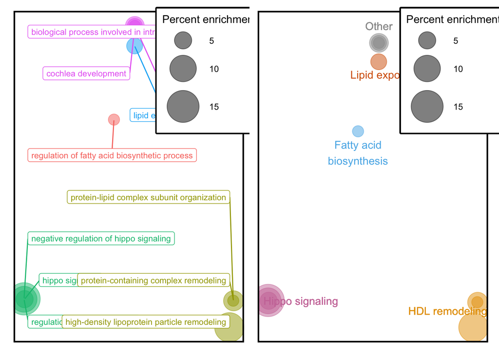

# STRING

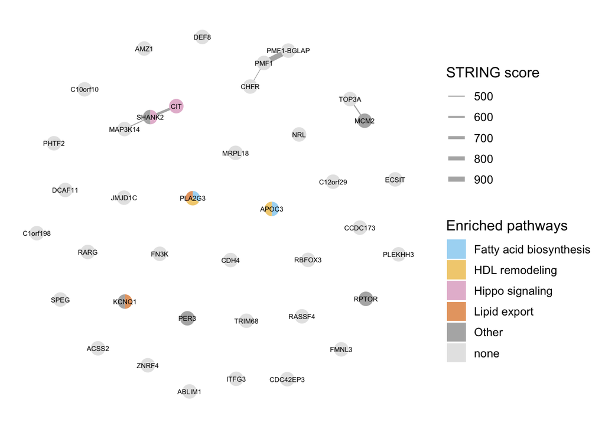

# Transcription factors

Lambert SA, Jolma A, Campitelli LF, Das PK, Yin Y, Albu M, Chen X, Taipale J, Hughes TR, Weirauch MT.(2018) The Human Transcription Factors. Cell. 172(4):650-665. doi: 10.1016/j.cell.2018.01.029. http://humantfs.ccbr.utoronto.ca/download.php

Are any DMR associated genes transcription factors?

```r
tx <- read_csv("data_Methyl_clean/DatabaseExtract_v_1.01.csv")
```

```
## ──────────────────────────────────────────────────────── Delimiter: "," chr
## (27): Ensembl ID, HGNC symbol, DBD, Is TF?, TF assessment, Binding mode,... dbl
## (1): ...1 lgl (1): Is C2H2 ZF(KRAB)?
```

```r
DMR.long <- DMR %>%
  mutate(gene_to_use = str_split(DMR_genes, "/")) %>%
  unnest(gene_to_use) %>%
  distinct(DMR, gene_to_use) %>%
  drop_na(gene_to_use)

tx %>%
  filter(`HGNC symbol` %in% gene.list[["DMR"]] &
           `Is TF?` =="Yes") %>%
  dplyr::select(`HGNC symbol`, `Is TF?`:`Motif status`) %>%
  left_join(DMR.long, by=c("HGNC symbol"="gene_to_use")) %>%
  kable() %>%
  kable_styling(bootstrap_options = "striped", full_width = FALSE)
```

| HGNC symbol | Is TF? | TF assessment | Binding mode | Motif status | DMR |
| --- | --- | --- | --- | --- | --- |
| NRL | Yes | Known motif | Monomer or homomultimer | High-throughput in vitro | DMR_33 |
| RARG | Yes | Known motif | Monomer or homomultimer | High-throughput in vitro | DMR_44 |